# Data_Minning_Project

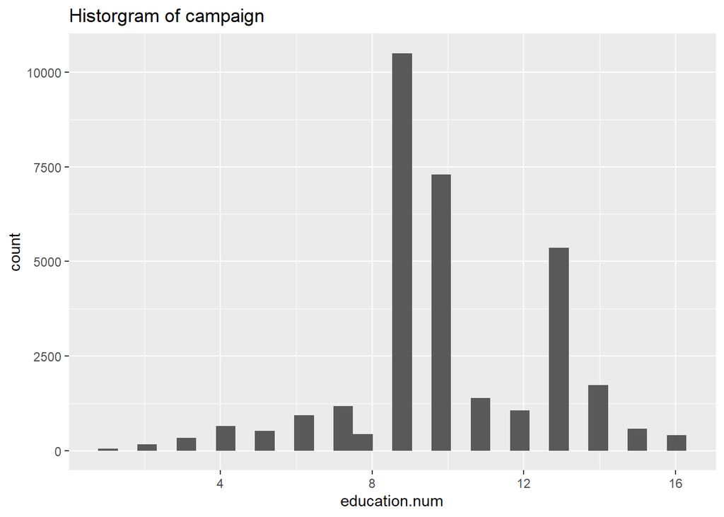

```r
census_data %>% ggplot()+                                                       #Distribution of histogram
  geom_histogram(aes(x=education.num),bins=30)+
  ggtitle('Historgram of campaign')
```

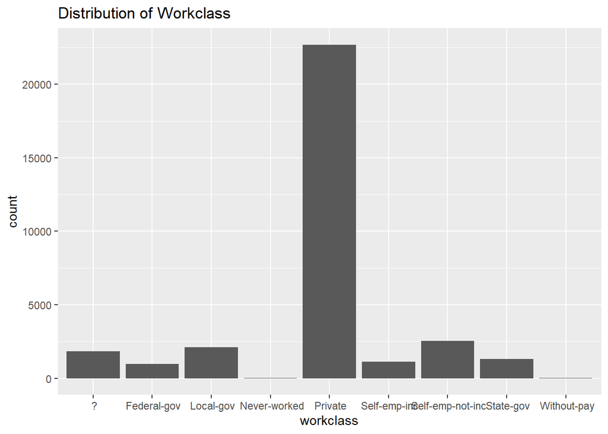

```r
# Bar chart of workclass
ggplot(census_data, aes(x = workclass)) +
  geom_bar() +
  labs(title = "Distribution of Workclass")
```

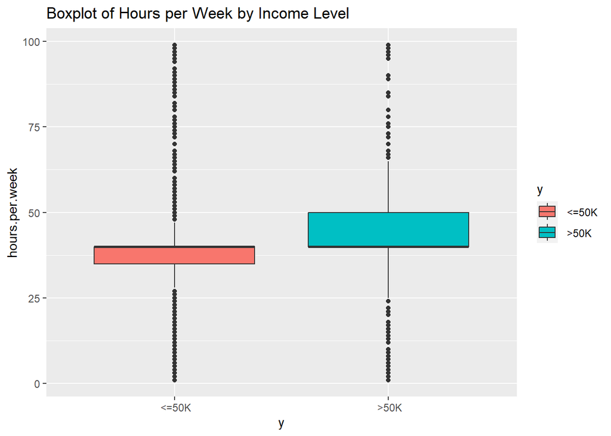

```r
# Boxplot of hours per week by income level
ggplot(census_data, aes(x = y, y = hours.per.week, fill = y)) +
  geom_boxplot() +
  labs(title = "Boxplot of Hours per Week by Income Level")
```

```r
#tabulation of education and income level
table(census_data$education, census_data$y)
```

```
##
##                  <=50K  >50K
##    10th            871    62
##    11th           1115    60
##    12th            400    33
##    1st-4th         162     6
##    5th-6th         317    16
##    7th-8th         606    40
##    9th             487    27
##    Assoc-acdm      802   265
##    Assoc-voc      1021   361
##    Bachelors      3134  2221
##    Doctorate       107   306
##    HS-grad        8826  1675
##    Masters         764   959
##    Preschool        51     0
##    Prof-school     153   423
##    Some-college   5904  1387
```

```r
# Proportion of individuals in each marital status category
census_data %>%
  group_by(marital.status) %>%
  summarise(count = n()) %>%
  mutate(percentage = count / sum(count) * 100)
```

```
## # A tibble: 7 × 3
##   marital.status           count percentage
##   <fct>                    <int>      <dbl>
## 1 " Divorced"               4443    13.6
## 2 " Married-AF-spouse"        23     0.0706
## 3 " Married-civ-spouse"    14976    46.0
## 4 " Married-spouse-absent"   418     1.28
## 5 " Never-married"         10683    32.8
## 6 " Separated"              1025     3.15
## 7 " Widowed"                 993     3.05
```

```r
# Correlation matrix for numerical variables
cor(census_data[, c("age", "fnlwgt", "education.num", "capital.gain", "capital.loss", "hours.per.week")])
```

```
##                        age        fnlwgt education.num  capital.gain
## age             1.00000000 -0.0766458679    0.03652719  0.0776744982
## fnlwgt         -0.07664587  1.0000000000   -0.04319463  0.0004318858
## education.num   0.03652719 -0.0431946327    1.00000000  0.1226301147
## capital.gain    0.07767450  0.0004318858    0.12263011  1.0000000000
## capital.loss    0.05777454 -0.0102517117    0.07992296 -0.0316150630
## hours.per.week  0.06875571 -0.0187684906    0.14812273  0.0784086154
##                capital.loss hours.per.week
## age              0.05777454     0.06875571
## fnlwgt          -0.01025171    -0.01876849
## education.num    0.07992296     0.14812273
## capital.gain    -0.03161506     0.07840862
## capital.loss     1.00000000     0.05425636
## hours.per.week   0.05425636     1.00000000
```

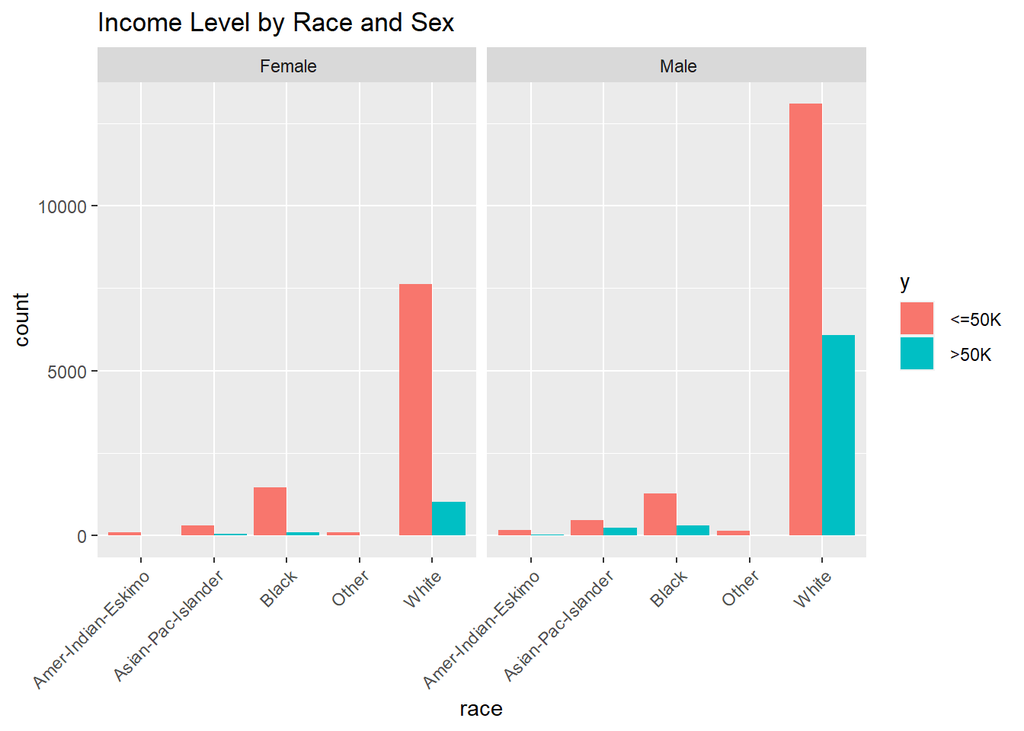

```r
# Bar chart of income level by race and sex
ggplot(census_data, aes(x = race, fill = y)) +
  geom_bar(position = "dodge") +
  facet_wrap(~sex) +
  labs(title = "Income Level by Race and Sex")+
  theme(axis.text.x = element_text(angle = 45, hjust = 1))
```

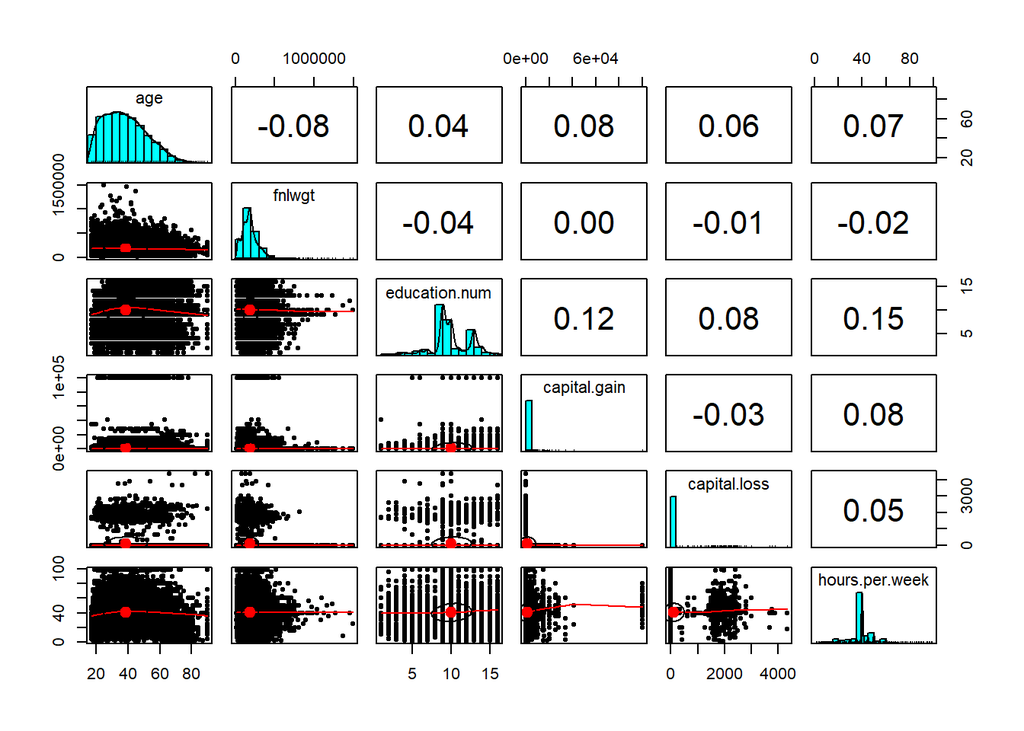

```r
#correlation with pairs.panels
pairs.panels(census_data[,c("age", "fnlwgt", "education.num", "capital.gain", "capital.loss", "hours.per.week")])
```

```r
census_data %>% pull(y) %>% nlevels()                                           #to show number of levels
```

```
## [1] 2
```

```r
census_data %>% select(y) %>% table()                                           #to get count of values of each level
```

```
## y
##  <=50K   >50K
##  24720   7841
```

```r
census_data %>% select(y) %>% table() %>% prop.table()%>% round(2)*100          #to get percentage of the values at each level
```

```
## y
##  <=50K   >50K
##     76     24
```

# 2 Task 2 Data Preparation

```r
summary(census_data)
```

```
##       age                    workclass         fnlwgt
##  Min.   :17.00    Private         :22696   Min.   :  12285
##  1st Qu.:28.00    Self-emp-not-inc: 2541   1st Qu.: 117827
##  Median :37.00    Local-gov       : 2093   Median : 178356
##  Mean   :38.58    ?               : 1836   Mean   : 189778
##  3rd Qu.:48.00    State-gov       : 1298   3rd Qu.: 237051
##  Max.   :90.00    Self-emp-inc    : 1116   Max.   :1484705
##                  (Other)          :  981
##          education     education.num                  marital.status
##   HS-grad     :10501   Min.   : 1.00    Divorced             : 4443
##   Some-college: 7291   1st Qu.: 9.00    Married-AF-spouse    :   23
##   Bachelors   : 5355   Median :10.00    Married-civ-spouse   :14976
##   Masters     : 1723   Mean   :10.08    Married-spouse-absent:  418
##   Assoc-voc   : 1382   3rd Qu.:12.00    Never-married        :10683
##   11th        : 1175   Max.   :16.00    Separated            : 1025
##  (Other)      : 5134                    Widowed              :  993
##             occupation            relationship                    race
##   Prof-specialty :4140    Husband       :13193    Amer-Indian-Eskimo:  311
##   Craft-repair   :4099    Not-in-family : 8305    Asian-Pac-Islander: 1039
##   Exec-managerial:4066    Other-relative:  981    Black             : 3124
##   Adm-clerical   :3770    Own-child     : 5068    Other             :  271
##   Sales          :3650    Unmarried     : 3446    White             :27816
##   Other-service  :3295    Wife          : 1568
##  (Other)         :9541
##       sex         capital.gain    capital.loss    hours.per.week
##   Female:10771   Min.   :    0   Min.   :   0.0   Min.   : 1.00
##   Male  :21790   1st Qu.:    0   1st Qu.:   0.0   1st Qu.:40.00
##                  Median :    0   Median :   0.0   Median :40.00
##                  Mean   : 1078   Mean   :  87.3   Mean   :40.44
##                  3rd Qu.:    0   3rd Qu.:   0.0   3rd Qu.:45.00
##                  Max.   :99999   Max.   :4356.0   Max.   :99.00
##
##         native.country       y
##   United-States:29170    <=50K:24720
##   Mexico       :  643    >50K : 7841
##   ?            :  583
##   Philippines  :  198
##   Germany      :  137
##   Canada       :  121
##  (Other)       : 1709
```

```r
census_data %>% distinct(capital.gain)
```

```
##     capital.gain
## 1           2174
## 2              0
## 3          14084
## 4           5178
## 5           5013
## 6           2407
## 7          14344
## 8          15024
## 9           7688
## 10         34095
## 11          4064
## 12          4386
## 13          7298
## 14          1409
```

[output cut: 105 more lines]

```r
census_data %>% distinct(capital.loss)
```

```
##    capital.loss
## 1             0
## 2          2042
## 3          1408
## 4          1902
## 5          1573
## 6          1887
## 7          1719
## 8          1762
## 9          1564
## 10         2179
## 11         1816
## 12         1980
## 13         1977
## 14         1876
```

[output cut: 78 more lines]

In Data Preparation:-

Scaling:- The range for fnlwgt is large so we can scale that to a smaller range using a log transformation so that it should not dominate in the model training.

```r
 # Remove the original User_Count (3th column)
log_census_data <- census_data[,-3]
# Create and add the natural log transformation of User_Count
log_census_data$log_fnlwgt <- log(census_data$fnlwgt)

summary(log_census_data)
```

```
##       age                    workclass             education
##  Min.   :17.00    Private         :22696    HS-grad     :10501
##  1st Qu.:28.00    Self-emp-not-inc: 2541    Some-college: 7291
##  Median :37.00    Local-gov       : 2093    Bachelors   : 5355
##  Mean   :38.58    ?               : 1836    Masters     : 1723
##  3rd Qu.:48.00    State-gov       : 1298    Assoc-voc   : 1382
##  Max.   :90.00    Self-emp-inc    : 1116    11th        : 1175
##                  (Other)          :  981   (Other)      : 5134
##  education.num                  marital.status             occupation
##  Min.   : 1.00    Divorced             : 4443    Prof-specialty :4140
##  1st Qu.: 9.00    Married-AF-spouse    :   23    Craft-repair   :4099
##  Median :10.00    Married-civ-spouse   :14976    Exec-managerial:4066
##  Mean   :10.08    Married-spouse-absent:  418    Adm-clerical   :3770
##  3rd Qu.:12.00    Never-married        :10683    Sales          :3650
##  Max.   :16.00    Separated            : 1025    Other-service  :3295
##                   Widowed              :  993   (Other)         :9541
##           relationship                    race            sex
##   Husband       :13193    Amer-Indian-Eskimo:  311    Female:10771
##   Not-in-family : 8305    Asian-Pac-Islander: 1039    Male  :21790
##   Other-relative:  981    Black             : 3124
##   Own-child     : 5068    Other             :  271
##   Unmarried     : 3446    White             :27816
##   Wife          : 1568
##
##   capital.gain    capital.loss    hours.per.week         native.country
##  Min.   :    0   Min.   :   0.0   Min.   : 1.00    United-States:29170
##  1st Qu.:    0   1st Qu.:   0.0   1st Qu.:40.00    Mexico       :  643
##  Median :    0   Median :   0.0   Median :40.00    ?            :  583
##  Mean   : 1078   Mean   :  87.3   Mean   :40.44    Philippines  :  198
##  3rd Qu.:    0   3rd Qu.:   0.0   3rd Qu.:45.00    Germany      :  137
##  Max.   :99999   Max.   :4356.0   Max.   :99.00    Canada       :  121
##                                                   (Other)       : 1709
##       y           log_fnlwgt
##   <=50K:24720   Min.   : 9.416
##   >50K : 7841   1st Qu.:11.677
##                 Median :12.092
##                 Mean   :11.984
##                 3rd Qu.:12.376
##                 Max.   :14.211
##
```

```r
set.seed(100)
inTrain <- createDataPartition(log_census_data$y, p=0.7, list=FALSE)                     #Splitting data into 70% training and 30% testing.
train_set<-log_census_data[inTrain,]
test_set<-log_census_data[-inTrain,]

train_set %>% str()
```

```
## 'data.frame':    22793 obs. of  15 variables:
##  $ age           : int  39 50 38 53 49 52 31 42 37 30 ...
##  $ workclass     : Factor w/ 9 levels " ?"," Federal-gov",..: 8 7 5 5 5 7 5 5 5 8 ...
##  $ education     : Factor w/ 16 levels " 10th"," 11th",..: 10 10 12 2 7 12 13 10 16 10 ...
##  $ education.num : int  13 13 9 7 5 9 14 13 10 13 ...
##  $ marital.status: Factor w/ 7 levels " Divorced"," Married-AF-spouse",..: 5 3 1 3 4 3 5 3 3 3 ...
##  $ occupation    : Factor w/ 15 levels " ?"," Adm-clerical",..: 2 5 7 7 9 5 11 5 5 11 ...
##  $ relationship  : Factor w/ 6 levels " Husband"," Not-in-family",..: 2 1 2 1 2 1 2 1 1 1 ...
##  $ race          : Factor w/ 5 levels " Amer-Indian-Eskimo",..: 5 5 5 3 3 5 5 5 3 2 ...
##  $ sex           : Factor w/ 2 levels " Female"," Male": 2 2 2 2 1 2 1 2 2 2 ...
##  $ capital.gain  : int  2174 0 0 0 0 0 14084 5178 0 0 ...
##  $ capital.loss  : int  0 0 0 0 0 0 0 0 0 0 ...
##  $ hours.per.week: int  40 13 40 40 16 45 50 40 80 40 ...
##  $ native.country: Factor w/ 42 levels " ?"," Cambodia",..: 40 40 40 40 24 40 40 40 40 20 ...
##  $ y             : Factor w/ 2 levels " <=50K"," >50K": 1 1 1 1 1 2 2 2 2 2 ...
##  $ log_fnlwgt    : num  11.3 11.3 12.3 12.4 12 ...
```

Other tasks that can be used is Encoding.

Define Evaluation Metrics: Choose appropriate evaluation metrics based on the nature of the problem. Common metrics include accuracy, precision, recall, F1 score, and R-squared.

Model Selection: Choose models that are suitable for the problem. Consider the complexity of the model and how well it matches the underlying patterns in your data.

Train Models: Train your selected models using the training data set. Use appropriate hyper parameters and consider using techniques like cross-validation.

Evaluate Metrics on Training and Validation Sets: Monitor model performance on both the training and validation sets. To get an understanding of how well the model performs to new and unseen data.

# 3 Task3 Model Building

```r
metrics_list1 <- c("ACC","PRECISION","TPR","F1")
metrics_list2 <- c("MAE","RMSE","MAPE","RMSPE","RAE", "RRSE", "R2")
```

### 3.0.1 C5.0 model using CF levels

```r
DS_model <- C5.0(formula = y~.,data = train_set,control = C5.0Control(CF=0,earlyStopping = FALSE,noGlobalPruning = FALSE))

DS_model
```

```
##
## Call:
## C5.0.formula(formula = y ~ ., data = train_set, control = C5.0Control(CF =
##  0, earlyStopping = FALSE, noGlobalPruning = FALSE))
##
## Classification Tree
## Number of samples: 22793
## Number of predictors: 14
##
## Tree size: 16
##
## Non-standard options: attempt to group attributes, confidence level: 0
```

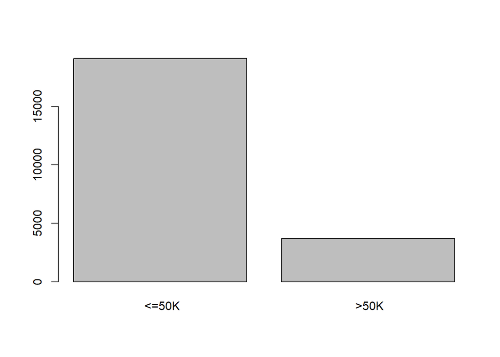

```r
train_predict1 <- predict(DS_model,train_set)
test_predict1 <- predict(DS_model,test_set)


plot(train_predict1)
```

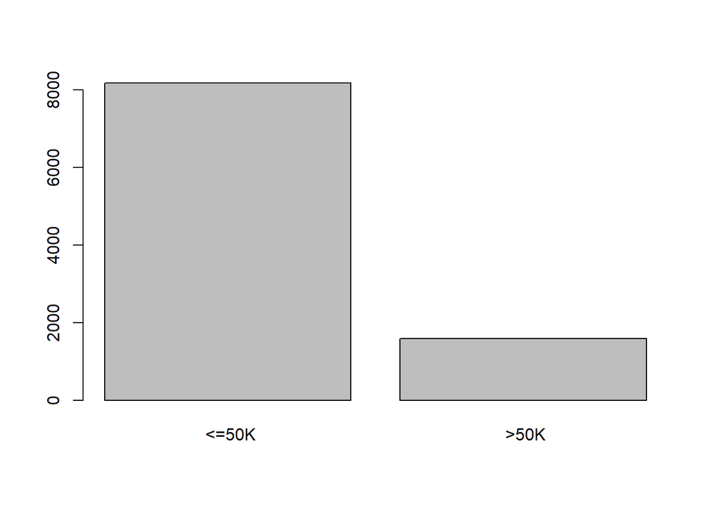

```r
plot(test_predict1)
```

```r
mmetric(train_set$y, train_predict1, metric="CONF")$conf
```

```
##         pred
## target    <=50K  >50K
##    <=50K  16619   685
##    >50K    2480  3009
```

```r
mmetric(train_set$y, train_predict1, metric=c("ACC","TPR","PRECISION","F1"))
```

```
##        ACC       TPR1       TPR2 PRECISION1 PRECISION2        F11        F12
##   86.11416   96.04138   54.81873   87.01503   81.45642   91.30566   65.53414
```

```r
mmetric(test_set$y, test_predict1, metric="CONF")$conf
```

```
##         pred
## target    <=50K  >50K
##    <=50K   7077   339
##    >50K    1105  1247
```

```r
mmetric(test_set$y, test_predict1, metric=c("ACC","TPR","PRECISION","F1"))
```

```
##        ACC       TPR1       TPR2 PRECISION1 PRECISION2        F11        F12
##   85.21704   95.42880   53.01871   86.49474   78.62547   90.74240   63.33164
```

### 3.0.2 Naïve Bayes and C5.0 with cross validation

```r
cv_function <- function(df, target, nFolds, seedVal, classification, metrics_list)
  {
  set.seed(seedVal)
  folds = createFolds(df[,target],nFolds)

  cv_results <- lapply(folds, function(x)
  {
    train <- df[-x,-target]
    test  <- df[x,-target]

    train_target <- df[-x,target]
    test_target <- df[x,target]

    classification_model <- classification(train,train_target)

    pred<- predict(classification_model,test)

    return(mmetric(test_target,pred,metrics_list))

  })
 cv_results_m <- as.matrix(as.data.frame(cv_results))

 cv_mean<- as.matrix(rowMeans(cv_results_m))

 colnames(cv_mean) <- "Mean"

 cv_sd <- as.matrix(rowSds(cv_results_m))

 colnames(cv_sd) <- "Sd"

 cv_all <- cbind(cv_results_m, cv_mean, cv_sd)

 kable(cv_all,digits=2)
}


metrics_list <- c("ACC","PRECISION","TPR","F1")

# the order here is unimportant because we have passed named arguments.

cv_function(metrics_list =  metrics_list1,
            df = log_census_data,
            target = 14,
            nFolds = 10,
            seed = 1234,
            classification =  C5.0)
```

|  | Fold01 | Fold02 | Fold03 | Fold04 | Fold05 | Fold06 | Fold07 | Fold08 | Fold09 | Fold10 | Mean | Sd |
| --- | --- | --- | --- | --- | --- | --- | --- | --- | --- | --- | --- | --- |
| ACC | 85.50 | 86.09 | 87.22 | 88.05 | 86.89 | 87.29 | 87.47 | 87.65 | 86.58 | 86.24 | 86.90 | 0.79 |
| PRECISION1 | 87.82 | 88.37 | 89.94 | 90.48 | 88.98 | 90.10 | 89.72 | 90.09 | 88.73 | 88.83 | 89.31 | 0.88 |
| PRECISION2 | 75.49 | 76.48 | 76.98 | 78.92 | 78.20 | 76.81 | 78.57 | 78.34 | 77.62 | 75.85 | 77.33 | 1.18 |
| TPR1 | 93.93 | 94.05 | 93.65 | 94.17 | 94.42 | 93.53 | 94.30 | 94.09 | 94.30 | 93.65 | 94.01 | 0.31 |
| TPR2 | 58.93 | 60.97 | 66.96 | 68.75 | 63.14 | 67.60 | 65.94 | 67.35 | 62.29 | 62.88 | 64.48 | 3.28 |
| F11 | 90.77 | 91.12 | 91.76 | 92.29 | 91.62 | 91.78 | 91.95 | 92.05 | 91.43 | 91.18 | 91.59 | 0.47 |
| F12 | 66.19 | 67.85 | 71.62 | 73.48 | 69.87 | 71.91 | 71.71 | 72.43 | 69.12 | 68.76 | 70.29 | 2.31 |

```r
cv_function(metrics_list =  metrics_list1,
            df = log_census_data,
            target = 14,
            nFolds = 10,
            seed = 1234,
            classification =  naiveBayes)
```

|  | Fold01 | Fold02 | Fold03 | Fold04 | Fold05 | Fold06 | Fold07 | Fold08 | Fold09 | Fold10 | Mean | Sd |
| --- | --- | --- | --- | --- | --- | --- | --- | --- | --- | --- | --- | --- |
| ACC | 81.33 | 81.54 | 83.91 | 83.51 | 82.74 | 83.20 | 83.20 | 83.08 | 83.08 | 83.45 | 82.90 | 0.83 |
| PRECISION1 | 84.09 | 84.51 | 86.32 | 85.69 | 85.29 | 86.20 | 85.79 | 86.15 | 85.17 | 85.55 | 85.48 | 0.73 |
| PRECISION2 | 66.86 | 66.79 | 72.65 | 72.66 | 70.18 | 69.85 | 70.90 | 69.45 | 72.24 | 72.81 | 70.44 | 2.27 |
| TPR1 | 93.00 | 92.68 | 93.65 | 93.97 | 93.37 | 92.72 | 93.33 | 92.60 | 94.09 | 94.09 | 93.35 | 0.59 |
| TPR2 | 44.52 | 46.43 | 53.19 | 50.51 | 49.23 | 53.19 | 51.28 | 53.06 | 48.41 | 49.87 | 49.97 | 2.94 |
| F11 | 88.32 | 88.40 | 89.83 | 89.64 | 89.15 | 89.34 | 89.40 | 89.26 | 89.41 | 89.62 | 89.24 | 0.50 |
| F12 | 53.45 | 54.78 | 61.41 | 59.59 | 57.87 | 60.39 | 59.51 | 60.16 | 57.97 | 59.20 | 58.43 | 2.53 |

### 3.0.3 Rpart

```r
cv_function1 <- function(df, target, nFolds, seedVal, prediction_method, metrics_list)
{
  # create folds
  set.seed(seedVal)
  folds = createFolds(df[,target],nFolds)
  # perform cross validation
  cv_results <- lapply(folds, function(x)
  {
    test_target <- df[x,target]
    test_input  <- df[x,-target]

    train_target <- df[-x,target]
    train_input <- df[-x,-target]

    prediction_model <- prediction_method(train_target~.,train_input)
    pred<- predict(prediction_model,test_input)
    return(mmetric(test_target,pred,metrics_list))
  })
  # generate means and sds and show cv results, means and sds using kable
  #cv_results_m <- as.matrix(as.data.frame(lapply(cv_results, as.character)))
  cv_results_m <- as.matrix(as.data.frame(cv_results))
  cv_mean<- as.matrix(rowMeans(cv_results_m))
 # print(class(cv_results_m))
  #str(cv_results_m)
  #print(cv_mean)
  #cv_results_m_numeric <- as.numeric(cv_results_m)
  cv_sd <- as.matrix(rowSds(cv_results_m))
  colnames(cv_mean) <- "Mean"
  colnames(cv_sd) <- "Sd"
  cv_all <- cbind(cv_results_m, cv_mean, cv_sd)
  kable(t(cv_all),digits=2)
}

cv_function1(log_census_data, 14, 5, 1234, rpart,metrics_list1)
```

|  | ACC | PRECISION1 | PRECISION2 | TPR1 | TPR2 | F11 | F12 |
| --- | --- | --- | --- | --- | --- | --- | --- |
| Fold1 | 84.06 | 85.85 | 74.93 | 94.60 | 50.86 | 90.01 | 60.59 |
| Fold2 | 83.89 | 85.60 | 74.93 | 94.72 | 49.74 | 89.93 | 59.79 |
| Fold3 | 85.20 | 86.74 | 77.55 | 95.02 | 54.21 | 90.69 | 63.81 |
| Fold4 | 84.67 | 85.87 | 78.16 | 95.53 | 50.45 | 90.44 | 61.32 |
| Fold5 | 84.43 | 86.03 | 76.18 | 94.90 | 51.40 | 90.25 | 61.39 |
| Mean | 84.45 | 86.02 | 76.35 | 94.96 | 51.33 | 90.27 | 61.38 |
| Sd | 0.52 | 0.43 | 1.48 | 0.36 | 1.72 | 0.31 | 1.51 |

### 3.0.4 IBK

```r
cv_IBk <- function(df, target, nFolds, seedVal, metrics_list, k, i)
{
# create folds using the assigned values

set.seed(seedVal)
folds = createFolds(df[,target],nFolds)

# The lapply loop

cv_results <- lapply(folds, function(x)
{
# data preparation:

  test_target <- df[x,target]
  test_input <- df[x,-target]

  train_target <- df[-x,target]
  train_input <- df[-x,-target]
  pred_model <- IBk(train_target ~ .,data = train_input,control = Weka_control(K=k,I=i))
  pred <- predict(pred_model, test_input)
  train_pred <- predict(pred_model, train_input)

  return(mmetric(test_target,pred,metrics_list))
})


cv_results_m <- as.matrix(as.data.frame(cv_results))

 cv_mean<- as.matrix(rowMeans(cv_results_m))

 colnames(cv_mean) <- "Mean"

 cv_sd <- as.matrix(rowSds(cv_results_m))

 colnames(cv_sd) <- "Sd"

 cv_all <- cbind(cv_results_m, cv_mean, cv_sd)

 kable(cv_all,digits=2)
}

cv_IBk(log_census_data, 14, 3, 1234, metrics_list1, 1, FALSE)
```

|  | Fold1 | Fold2 | Fold3 | Mean | Sd |
| --- | --- | --- | --- | --- | --- |
| ACC | 79.70 | 78.78 | 79.38 | 79.29 | 0.47 |
| PRECISION1 | 86.46 | 86.12 | 86.16 | 86.24 | 0.19 |
| PRECISION2 | 57.98 | 55.88 | 57.36 | 57.08 | 1.08 |
| TPR1 | 86.87 | 85.90 | 86.78 | 86.52 | 0.54 |
| TPR2 | 57.12 | 56.33 | 56.04 | 56.50 | 0.55 |
| F11 | 86.66 | 86.01 | 86.47 | 86.38 | 0.34 |
| F12 | 57.54 | 56.11 | 56.70 | 56.78 | 0.72 |

### 3.0.5 SVM cross validation

```r
cv_function_ksvm <- function(df, target, nFolds, seedVal, metrics_list, kern, c)
{
# create folds using the assigned values

set.seed(seedVal)
folds = createFolds(df[,target],nFolds)

# The lapply loop

cv_results <- lapply(folds, function(x)
{
# data preparation:

  test_target <- df[x,target]
  test_input <- df[x,-target]

  train_target <- df[-x,target]
  train_input <- df[-x,-target]
   pred_model <- ksvm(train_target ~ .,data = train_input,kernel=kern,C=c)
  pred <- predict(pred_model, test_input)
  return(mmetric(test_target,pred,metrics_list))
})

cv_results_m <- as.matrix(as.data.frame(cv_results))

 cv_mean<- as.matrix(rowMeans(cv_results_m))

 colnames(cv_mean) <- "Mean"

 cv_sd <- as.matrix(rowSds(cv_results_m))

 colnames(cv_sd) <- "Sd"

 cv_all <- cbind(cv_results_m, cv_mean, cv_sd)

 kable(cv_all,digits=2)
}

### Compare two classification costs

tic()
cv_function_ksvm(log_census_data, 14, 5, 1234, metrics_list1, 'rbfdot', 7)
```

|  | Fold1 | Fold2 | Fold3 | Fold4 | Fold5 | Mean | Sd |
| --- | --- | --- | --- | --- | --- | --- | --- |
| ACC | 85.15 | 85.55 | 86.12 | 85.63 | 85.52 | 85.59 | 0.35 |
| PRECISION1 | 88.15 | 87.93 | 89.27 | 88.11 | 88.10 | 88.31 | 0.54 |
| PRECISION2 | 73.15 | 75.38 | 74.27 | 75.20 | 74.78 | 74.56 | 0.89 |
| TPR1 | 92.94 | 93.85 | 92.88 | 93.71 | 93.57 | 93.39 | 0.45 |
| TPR2 | 60.61 | 59.38 | 64.80 | 60.14 | 60.14 | 61.01 | 2.16 |
| F11 | 90.48 | 90.79 | 91.04 | 90.83 | 90.75 | 90.78 | 0.20 |
| F12 | 66.29 | 66.43 | 69.21 | 66.83 | 66.67 | 67.09 | 1.21 |

```r
cv_function_ksvm(log_census_data, 14, 5, 1234, metrics_list1, 'laplacedot', 7)
```

|  | Fold1 | Fold2 | Fold3 | Fold4 | Fold5 | Mean | Sd |
| --- | --- | --- | --- | --- | --- | --- | --- |
| ACC | 85.60 | 85.64 | 85.95 | 85.96 | 85.43 | 85.72 | 0.23 |
| PRECISION1 | 88.58 | 88.16 | 89.34 | 88.63 | 88.38 | 88.62 | 0.44 |
| PRECISION2 | 73.88 | 75.14 | 73.47 | 75.23 | 73.68 | 74.28 | 0.84 |
| TPR1 | 93.02 | 93.67 | 92.54 | 93.51 | 93.04 | 93.16 | 0.45 |
| TPR2 | 62.21 | 60.33 | 65.18 | 62.18 | 61.42 | 62.26 | 1.80 |
| F11 | 90.75 | 90.83 | 90.91 | 91.00 | 90.65 | 90.83 | 0.14 |
| F12 | 67.54 | 66.93 | 69.08 | 68.09 | 66.99 | 67.72 | 0.89 |

```r
toc()
```

```
## 1057.14 sec elapsed
```